# Sklearn 分类学习算法一览

```python
# !pip install -U scikit-learn
import sklearn
sklearn.__version__
```

```
'1.3.2'
```

# 机器学习算法选择

## scikit-learn 初探

scikit-learn中自带了一些数据集，比如说最著名的Iris数据集。

根据鸢尾花(iris)的四个尺寸:花瓣长度(petal_length)、花瓣宽度 (petal_width)、花萼长度(sepal_length)、花萼宽度(sepal_width)， 判断出花的种类。

我们已经采集到一批测量数据，需要根据这些数据通过机器学习建立数据模型，用于判断鸢尾花的种类。

数据集中第3列和第4列数据表示花瓣的长度和宽度。而类别已经转成了数字，比如

> 0=Iris-Setosa

> 1=Iris-Versicolor

> 2=Iris-Virginica

[figure not shown]

### 加载数据

```python
from sklearn import datasets
import numpy as np

# The iris dataset is a classic and very easy multi-class classification
# dataset.

# =================   ==============
# Classes                          3
# Samples per class               50
# Samples total                  150
# Dimensionality                   4
# Features            real, positive
# =================   ==============
iris = datasets.load_iris()
```

```python
# 数据描述
print(iris.DESCR)
```

```
.. _iris_dataset:

Iris plants dataset
--------------------

**Data Set Characteristics:**

    :Number of Instances: 150 (50 in each of three classes)
    :Number of Attributes: 4 numeric, predictive attributes and the class
    :Attribute Information:
        - sepal length in cm
        - sepal width in cm
        - petal length in cm
        - petal width in cm
        - class:
                - Iris-Setosa
                - Iris-Versicolour
                - Iris-Virginica

    :Summary Statistics:

    ============== ==== ==== ======= ===== ====================
                    Min  Max   Mean    SD   Class Correlation
    ============== ==== ==== ======= ===== ====================
    sepal length:   4.3  7.9   5.84   0.83    0.7826
    sepal width:    2.0  4.4   3.05   0.43   -0.4194
    petal length:   1.0  6.9   3.76   1.76    0.9490  (high!)
    petal width:    0.1  2.5   1.20   0.76    0.9565  (high!)
    ============== ==== ==== ======= ===== ====================

    :Missing Attribute Values: None
    :Class Distribution: 33.3% for each of 3 classes.
    :Creator: R.A. Fisher
    :Donor: Michael Marshall (MARSHALL%PLU@io.arc.nasa.gov)
    :Date: July, 1988

The famous Iris database, first used by Sir R.A. Fisher. The dataset is taken
from Fisher's paper. Note that it's the same as in R, but not as in the UCI
Machine Learning Repository, which has two wrong data points.

```

[output cut: 12 more lines]

```
  Annual Eugenics, 7, Part II, 179-188 (1936); also in "Contributions to
  Mathematical Statistics" (John Wiley, NY, 1950).
- Duda, R.O., & Hart, P.E. (1973) Pattern Classification and Scene Analysis.
  (Q327.D83) John Wiley & Sons.  ISBN 0-471-22361-1.  See page 218.
- Dasarathy, B.V. (1980) "Nosing Around the Neighborhood: A New System
  Structure and Classification Rule for Recognition in Partially Exposed
  Environments".  IEEE Transactions on Pattern Analysis and Machine
  Intelligence, Vol. PAMI-2, No. 1, 67-71.
- Gates, G.W. (1972) "The Reduced Nearest Neighbor Rule".  IEEE Transactions
  on Information Theory, May 1972, 431-433.
- See also: 1988 MLC Proceedings, 54-64.  Cheeseman et al"s AUTOCLASS II
  conceptual clustering system finds 3 classes in the data.
- Many, many more ...

|details-end|
```

### 读取特征和标签

```python
iris.data.shape
```

```
(150, 4)
```

```python
iris.target
```

```
array([0, 0, 0, 0, 0, 0, 0, 0, 0, 0, 0, 0, 0, 0, 0, 0, 0, 0, 0, 0, 0, 0,
       0, 0, 0, 0, 0, 0, 0, 0, 0, 0, 0, 0, 0, 0, 0, 0, 0, 0, 0, 0, 0, 0,
       0, 0, 0, 0, 0, 0, 1, 1, 1, 1, 1, 1, 1, 1, 1, 1, 1, 1, 1, 1, 1, 1,
       1, 1, 1, 1, 1, 1, 1, 1, 1, 1, 1, 1, 1, 1, 1, 1, 1, 1, 1, 1, 1, 1,
       1, 1, 1, 1, 1, 1, 1, 1, 1, 1, 1, 1, 2, 2, 2, 2, 2, 2, 2, 2, 2, 2,
       2, 2, 2, 2, 2, 2, 2, 2, 2, 2, 2, 2, 2, 2, 2, 2, 2, 2, 2, 2, 2, 2,
       2, 2, 2, 2, 2, 2, 2, 2, 2, 2, 2, 2, 2, 2, 2, 2, 2, 2])
```

```python
X = iris.data[:, [2, 3]]  # 仅取 petal length 和 petal width 两个特征为例
y = iris.target

print('Data shape:', X.shape)
print('Class labels:', np.unique(y))
```

```
Data shape: (150, 2)
Class labels: [0 1 2]
```

### 数据切分

通常我们会把数据集切分成训练集和测试集，这里70%的训练集，30%的测试集。

```python
from sklearn.model_selection import train_test_split
X_train, X_test, y_train, y_test = train_test_split(X, y, test_size=0.3, shuffle=True, random_state=0)

# 查看数据的维度
X_train.shape, X_test.shape, y_train.shape, y_test.shape
```

```
((105, 2), (45, 2), (105,), (45,))
```

### 对特征做标准化

[figure not shown]

```python
from sklearn.preprocessing import StandardScaler

sc = StandardScaler()  # 对数据的每一列做了一个归一化
sc.fit(X_train)
```

```
StandardScaler()
```

```python
sc.mean_
```

```
array([3.82857143, 1.22761905])
```

```python
sc.scale_
```

```
array([1.79595918, 0.77637684])
```

```python
X_train_std = sc.transform(X_train)
X_test_std = sc.transform(X_test)
```

```python
# Check
np.mean(X_train, axis=0), np.std(X_train, axis=0)
```

```
(array([3.82857143, 1.22761905]), array([1.79595918, 0.77637684]))
```

```python
# Check
np.mean(X_train_std, axis=0), np.std(X_train_std, axis=0)
# np.mean(X_test_std, axis=0), np.std(X_test_std, axis=0)
```

```
(array([-3.59500789e-16,  7.82442894e-17]), array([1., 1.]))
```

## 机器学习分类模型建模

我们先用`plot_decision_region`函数来做一个可视化，方便一会儿直观看分类结果。

```python
from matplotlib.colors import ListedColormap
import matplotlib.pyplot as plt
import warnings


def versiontuple(v):
    return tuple(map(int, (v.split("."))))


def plot_decision_regions(X, y, classifier, test_idx=None, resolution=0.02):

    # setup marker generator and color map
    markers = ('s', 'x', 'o', '^', 'v')
    colors = ('red', 'blue', 'lightgreen', 'gray', 'cyan')
    cmap = ListedColormap(colors[:len(np.unique(y))])

    # plot the decision surface
    x1_min, x1_max = X[:, 0].min() - 1, X[:, 0].max() + 1
    x2_min, x2_max = X[:, 1].min() - 1, X[:, 1].max() + 1
    xx1, xx2 = np.meshgrid(np.arange(x1_min, x1_max, resolution),
                           np.arange(x2_min, x2_max, resolution))
    Z = classifier.predict(np.array([xx1.ravel(), xx2.ravel()]).T)
    Z = Z.reshape(xx1.shape)
    plt.contourf(xx1, xx2, Z, alpha=0.4, cmap=cmap)
    plt.xlim(xx1.min(), xx1.max())
    plt.ylim(xx2.min(), xx2.max())

    for idx, cl in enumerate(np.unique(y)):
        plt.scatter(x=X[y == cl, 0], y=X[y == cl, 1],
                    alpha=0.8, c=np.array([cmap(idx)]),
                    marker=markers[idx], label=cl)

    # highlight test samples
    if test_idx:
        # plot all samples
        if not versiontuple(np.__version__) >= versiontuple('1.9.0'):
            X_test, y_test = X[list(test_idx), :], y[list(test_idx)]
            warnings.warn('Please update to NumPy 1.9.0 or newer')
        else:
            X_test, y_test = X[test_idx, :], y[test_idx]

        plt.scatter(X_test[:, 0],
                    X_test[:, 1],
                    alpha=0.15,
                    linewidths=2,
                    marker='^',
                    edgecolors='black',
                    facecolors='none',
                    s=55, label='test set')
```

### 感知器

[figure not shown]

- m: num of samples
- n: num of features
- k: num of classes

$X_{mn} * W_{nk} = Y_{mk}$

```python
from sklearn.linear_model import Perceptron

# 初始化一个感知器
ppn = Perceptron(max_iter=40, eta0=0.1, random_state=0)
# ppn = Perceptron(max_iter=5)
```

```python
X_train_std.shape
```

```
(105, 2)
```

```python
ppn.fit(X_train_std, y_train)
```

```
Perceptron(eta0=0.1, max_iter=40)
```

```python
# Weights assigned to the features. (n_classes, n_features)
ppn.coef_
```

```
array([[-0.09306607, -0.07372463],
       [ 0.16306448, -0.25404943],
       [ 0.29033431,  0.24607589]])
```

```python
# Constants in decision function.  (n_classes,)
ppn.intercept_
```

```
array([-0.1, -0.1, -0.4])
```

```python
(X_test_std @ ppn.coef_.T)
(X_test_std @ ppn.coef_.T + ppn.intercept_).argmax(axis=1)
```

```
array([2, 1, 0, 2, 0, 2, 0, 1, 1, 1, 1, 1, 1, 1, 1, 0, 1, 1, 0, 0, 2, 1,
       0, 0, 2, 0, 0, 1, 0, 0, 2, 1, 0, 2, 2, 0, 0, 2, 0, 1, 2, 0, 2, 0,
       0])
```

```python
y_pred = ppn.predict(X_test_std)
```

```python
y_pred
```

```
array([2, 1, 0, 2, 0, 2, 0, 1, 1, 1, 1, 1, 1, 1, 1, 0, 1, 1, 0, 0, 2, 1,
       0, 0, 2, 0, 0, 1, 0, 0, 2, 1, 0, 2, 2, 0, 0, 2, 0, 1, 2, 0, 2, 0,
       0])
```

```python
y_test
```

```
array([2, 1, 0, 2, 0, 2, 0, 1, 1, 1, 2, 1, 1, 1, 1, 0, 1, 1, 0, 0, 2, 1,
       0, 0, 2, 0, 0, 1, 1, 0, 2, 1, 0, 2, 2, 1, 0, 1, 1, 1, 2, 0, 2, 0,
       0])
```

```python
y_pred == y_test
```

```
array([ True,  True,  True,  True,  True,  True,  True,  True,  True,
        True, False,  True,  True,  True,  True,  True,  True,  True,
        True,  True,  True,  True,  True,  True,  True,  True,  True,
        True, False,  True,  True,  True,  True,  True,  True, False,
        True, False, False,  True,  True,  True,  True,  True,  True])
```

```python
print('Misclassified samples: %d' % (y_test != y_pred).sum())
```

```
Misclassified samples: 5
```

```python
from sklearn.metrics import accuracy_score

print('Accuracy: %.2f' % accuracy_score(y_test, y_pred))
```

```
Accuracy: 0.89
```

用标准化的数据做一个感知器分类器

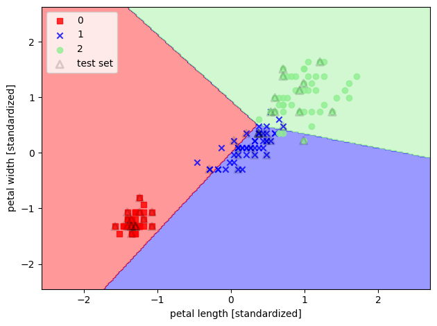

```python
%matplotlib inline
X_combined_std = np.vstack((X_train_std, X_test_std))
y_combined = np.hstack((y_train, y_test))

plot_decision_regions(X=X_combined_std, y=y_combined,
                      classifier=ppn, test_idx=range(105, 150))
plt.xlabel('petal length [standardized]')
plt.ylabel('petal width [standardized]')
plt.legend(loc='upper left')

plt.tight_layout()
plt.show()
```

### 逻辑回归(Logistic Regression)

[figure not shown]

[figure not shown]

$X_{mn} * W_{nk} = Y_{mk}$

- m: num of samples
- n: num of features
- k: num of classes

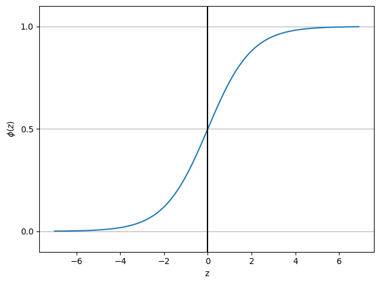

```python
# 感受一般
def sigmoid(z):
    return 1.0 / (1.0 + np.exp(-z))

z = np.arange(-7, 7, 0.1)
phi_z = sigmoid(z)
plt.plot(z, phi_z)
plt.axvline(0.0, color='k')
plt.ylim(-0.1, 1.1)
plt.xlabel('z')
plt.ylabel('$\phi (z)$')
# y axis ticks and gridline
plt.yticks([0.0, 0.5, 1.0])
ax = plt.gca()
ax.yaxis.grid(True)
plt.tight_layout()
plt.show()
```

**点击折叠/展开**

- 构筑对数似然函数

二分类模型的标签是 $[0,1]$ ，此标签服从伯努利分布(即0-1分布)，因此可得: 样本在由特征向量 $x_i$ 和权重向量 $\boldsymbol{w}$ 组成的预测函数中，样本标签被预测为 1 的概率为: $$ P_1=P\left(\hat{y}_i=1 \mid \boldsymbol{x}_i, \boldsymbol{w}\right)=\sigma $$

对二分类而言， $\sigma$ 就是sigmoid函数的结果。 样本 $\mathrm{i}$ 在由特征向量 $\mathrm{x}_{\mathrm{i}}$ 和权重向量 $\mathrm{w}$ 组成的预测函数中，样本标签被预测为 0 的概率为: $$ P_0=P\left(\hat{y}_i=0 \mid \boldsymbol{x}_i, \boldsymbol{w}\right)=1-\sigma $$

当 $P_1$ 的值为 1 的时候，代表样本 $i$ 的标签被预測为 1 ，当 $P_0$ 的值为 1 的时候，代表样本i的标签被预测为 0 。 $P_1$ 与 $P_0$ 相加是一定等于 1 的。

假设样本啲真实标签 $y_i$ 为 1 ，并且 $P_1$ 也为 1 的话，那就说明我们将 $i$ 的标签预测为 1 的概率很大，与真实值一致，那模型的预测就是准确的，拟合程度很高，信息损失很少。相反，如果真实标签 $y_i$ 为 1 ，我们的 $P_1$ 却很接近 0 ，这就说明我们将 $i$ 的标签预测为 1 的概率很小，即与真实值一致的概率很小，那模型的预测就是失败的，拟合程度很低，信息损失很多。当 $y_i$ 为 0 时，也是同样的道理。所以，当 $y_i$ 为 1 的时候，我们希望 $P_1$ 非常接近 1 ，当 $y_i$ 为 0 的时候，我们希望 $P_0$ 非常接近 1 ，这样，模型的效果就很好，信息损失就很少。

将两种取值的概率整合，我们可以定义如下等式： $$ P\left(\hat{y}_i \mid \boldsymbol{x}_i, \boldsymbol{w}\right)=P_1^{y_i} * P_0^{1-y_i} $$

这个等式代表同时代表了 $P_1$ 和 $P_0$ ，在数学上，它被叫做逻辑回归的假设函数。 当样本菂真实标签 $y_i$ 为 1 的时候， $1-y_i$ 就等于 $0 ， P_0$ 的0次方就是1，所以 $P\left(\hat{y}_i \mid \boldsymbol{x}_{\boldsymbol{i}}, \boldsymbol{w}\right)$ 就等于 $P_1$ ，这个时候，如果 $P_1$ 为 1 ，模型的效果就很好，损失就很小。

同理，当 $y_i$ 为 0 的时候， $P\left(\hat{y}_i \mid \boldsymbol{x}_i, \boldsymbol{w}\right)$ 就等于 $P_0$ ，此时如果 $P_0$ 非常接近1，模型的效果就很好，损失就很小。

所以，为了达成让模型拟合好，损失小的目的，我们每时每刻都希望 $P\left(\hat{y}_i \mid x_i, w\right)$ 的值等于1。而 $P\left(\hat{y}_i \mid \boldsymbol{x}_{\boldsymbol{i}}, \boldsymbol{w}\right)$ 的本质是样本油特征向量 $\boldsymbol{x}_{\boldsymbol{i}}$ 和权重 $\boldsymbol{w}$ 组成的预测函数中，预测出所有可能的 $\hat{y}_i$ 的概率，因此1是它的最大值。也就是说，每时每刻，我们都在追求 $P\left(\hat{y}_i \mid \boldsymbol{x}_i, w\right)$ 的最大值。而寻找相应的参数 $w$ ，使得每次得到的预测概率最大，正是极大似然估计的基本方法，不过 $P\left(\hat{y}_i \mid \boldsymbol{x}_{\boldsymbol{i}}, \boldsymbol{w}\right)$ 是对单个样本而言的，因此我们还需要将其拓展到多个样本上。

$P\left(\hat{y}_i \mid \boldsymbol{x}_i, \boldsymbol{w}\right)$ 是对单个样本而言的函数，对一个训练集的 $\mathrm{m}$ 个样本来说，我们可以定义如下等式来表达所有样本在特征张量 $\boldsymbol{X}$ 和权重向量 $\boldsymbol{w}$ 组成的预测函数中，预测出所有可能的 $\hat{y}$ 的概率 $\mathrm{P}$ 为: $$ \begin{aligned} \boldsymbol{P} & =\prod_{i=1}^m P\left(\hat{y}_i \mid x_i, w\right) \\ & =\prod_{i=1}^m\left(P_1^{y_i} * P_0^{1-y_i}\right) \\ & =\prod_{i=1}^m\left(\sigma_i^{y_i} *\left(1-\sigma_i\right)^{1-y_i}\right) \end{aligned} $$

这个函数就是逻辑回归的似然函数。对该概率P取以e为底的对数，再由 $\log (A * B)=\log A+\log B$ 和 $\log A^B=B \log A$ 可得到逻辑回归的对数似然函数:

$$ \begin{aligned} \ln \boldsymbol{P} & =\ln \prod_{i=1}^m\left(\sigma_i^{y_i} *\left(1-\sigma_i\right)^{1-y_i}\right) \\ & =\sum_{i=1}^m \ln \left(\sigma_i^{y_i} *\left(1-\sigma_i\right)^{1-y_i}\right) \\ & =\sum_{i=1}^m\left(\ln \sigma_i^{y_i}+\ln \left(1-\sigma_i\right)^{1-y_i}\right) \\ & =\sum_{i=1}^m\left(y_i * \ln \left(\sigma_i\right)+\left(1-y_i\right) * \ln \left(1-\sigma_i\right)\right) \end{aligned} $$

这就是我们的二分类交叉嫡函数。为了数学上的便利以及更好地定义"损失“的含义，我们希望将极大值问题转换为极小值问题，因此我们对 $\ln P$ 取负，并且让权重 $w$ 作为函数的自变量，就得到了我们的损失函数 $L(w)$ : $$ L(w)=-\sum_{i=1}^m\left(y_i * \ln \left(\sigma_i\right)+\left(1-y_i\right) * \ln \left(1-\sigma_i\right)\right) $$

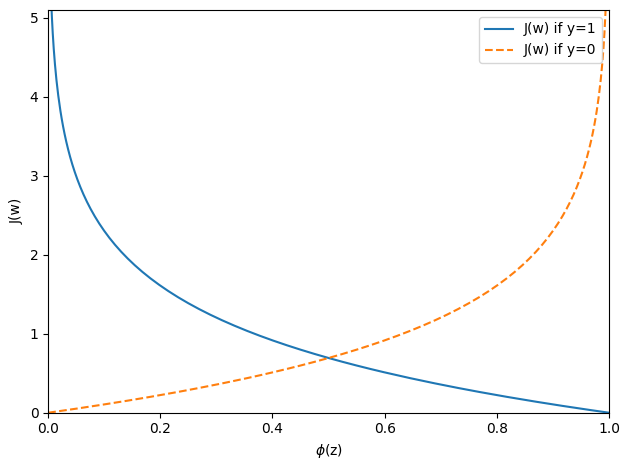

```python
# 通过最小化损失函数求解权重
def cost_1(z):
    return - np.log(sigmoid(z))
def cost_0(z):
    return - np.log(1 - sigmoid(z))

z = np.arange(-10, 10, 0.1)
phi_z = sigmoid(z)
c1 = [cost_1(x) for x in z]
plt.plot(phi_z, c1, label='J(w) if y=1')
c0 = [cost_0(x) for x in z]
plt.plot(phi_z, c0, linestyle='--', label='J(w) if y=0')
plt.ylim(0.0, 5.1)
plt.xlim([0, 1])
plt.xlabel('$\phi$(z)')
plt.ylabel('J(w)')
plt.legend(loc='best')
plt.tight_layout()
plt.show()

# 这段代码是在展示逻辑回归中的损失函数如何随着预测概率的变化而变化。在逻辑回归中，我们使用sigmoid函数将线性函数的输出转换为概率，这个概率用于二分类任务。
# 函数cost_1(z)和cost_0(z)分别计算当真实类别为1和0时的损失。如果真实类别是1，我们希望模型预测的概率尽可能接近1，此时损失函数cost_1(z)的值会接近0；
# 反之，如果模型预测的概率接近0，损失函数的值会变大。同理，如果真实类别是0，我们希望模型预测的概率尽可能接近0，此时损失函数cost_0(z)的值会接近0；反之，如果模型预测的概率接近1，损失函数的值会变大。
# 在这段代码中，我们计算了在不同的预测概率（由phi_z表示）下，两种情况的损失函数值，并将它们绘制在同一张图上。这样可以直观地看到，当预测概率与真实类别越接近时，损失函数的值越小，这就是我们在训练逻辑回归模型时要最小化损失函数的原因。
```

**点击折叠/展开**

- penalty: 正则化选择参数（惩罚项的种类），默认方式为L2正则化
  - LogisticRegression默认带了正则化项。penalty参数可选择的值为"l1"和"l2".分别对应L1的正则化和L2的正则化，默认是L2的正则化。
  - 在调参时如果我们主要的目的只是为了解决过拟合，一般penalty选择L2正则化就够了。但是如果选择L2正则化发现还是过拟合，即预测效果差的时候，就可以考虑L1正则化。
  - 另外，如果模型的特征非常多，我们希望一些不重要的特征系数归零，从而让模型系数稀疏化的话，也可以使用L1正则化。
  - penalty参数的选择会影响我们损失函数优化算法的选择。即参数solver的选择，如果是L2正则化，那么4种可选的算法{‘newton-cg’, ‘lbfgs’, ‘liblinear’, ‘sag’}都可以选择。
  - 但是如果penalty是L1正则化的话，就只能选择‘liblinear’了。这是因为L1正则化的损失函数不是连续可导的，而{‘newton-cg’, ‘lbfgs’,‘sag’}这三种优化算法时都需要损失函数的一阶或者二阶连续导数。而‘liblinear’并没有这个依赖。
- C: 正则项系数的倒数，通常默认为1
- solver: 对于多分类任务， 使用‘newton-cg’, ‘sag’, ‘saga’ and ‘lbfgs’ 来解决多项式loss
- multi_class: 默认值‘ovr’适用于二分类问题，对于多分类问题，用‘multinomial’在全局的概率分布上最小化损失

Ref: https://blog.csdn.net/weixin_41712499/article/details/82526483

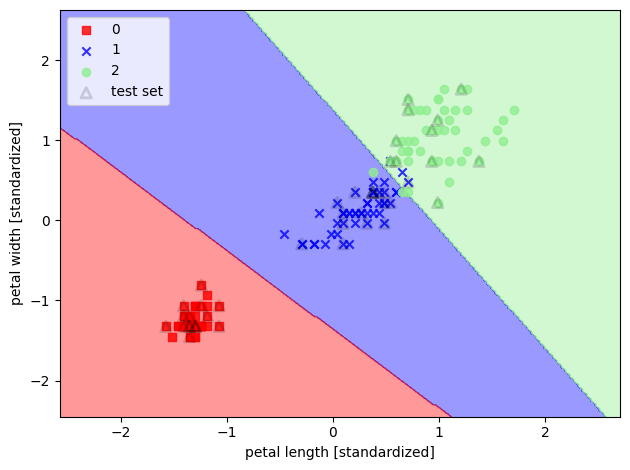

```python
from sklearn.linear_model import LogisticRegression

lr = LogisticRegression(C=1000.0, max_iter=100, random_state=0)
lr.fit(X_train_std, y_train)

plot_decision_regions(X_combined_std, y_combined,
                      classifier=lr, test_idx=range(105, 150))
plt.xlabel('petal length [standardized]')
plt.ylabel('petal width [standardized]')
plt.legend(loc='upper left')
plt.tight_layout()
plt.show()
```

```python
lr.predict_proba(X_test_std[0, :].reshape(1, -1))
```

```
array([[6.51335792e-16, 4.95077314e-04, 9.99504923e-01]])
```

```python
[f'{i:.4f}' for i in _[0]]
```

```
['0.0000', '0.0005', '0.9995']
```

```python
y_test[0]
```

```
2
```

```python
# 这个函数首先从输入数组中减去最大值（为了增加数值稳定性），然后对结果应用指数函数，最后将结果归一化，使得所有元素的和为1。
# 这样，softmax函数的输出可以被解释为概率分布。
def softmax(x):
    e_x = np.exp(x - np.max(x))
    return e_x / e_x.sum(axis=0)
```

```python
X_test_std[:1] @ lr.coef_.T + lr.intercept_
```

```
array([[-20.77457363,   6.58213611,  14.19243752]])
```

```python
# check
softmax((X_test_std[:1] @ lr.coef_.T + lr.intercept_)[0])
```

```
array([6.51335792e-16, 4.95077314e-04, 9.99504923e-01])
```

```python
# check
[f'{i:.4f}' for i in _]
```

```
['0.0000', '0.0005', '0.9995']
```

### 附：过拟合/overfitting 与 正则化/regularization

参考知乎问题

> ① [用简单易懂的语言描述「过拟合 overfitting」](https://www.zhihu.com/question/32246256/answer/83898785)

> ② [机器学习中常常提到的正则化到底是什么意思](https://www.zhihu.com/question/20924039)

[figure not shown]

正则化是一种用于防止过拟合的技术，它通过在损失函数中添加一个正则项来限制模型的复杂度。在逻辑回归中，我们通常使用L1或L2正则化。

- 对于L2正则化（也称为岭回归或权重衰减），损失函数为：

`J(w) = -[y log(σ(w^T x)) + (1 - y) log(1 - σ(w^T x))] + λ/2 ||w||^2`

其中，σ(w^T x)是sigmoid函数，||w||^2是权重向量的L2范数（即权重的平方和），λ是正则化强度。

- 对于L1正则化（也称为Lasso回归），损失函数为：

`J(w) = -[y log(σ(w^T x)) + (1 - y) log(1 - σ(w^T x))] + λ ||w||`

其中，||w||是权重向量的L1范数（即权重的绝对值之和）。

- 探索逻辑回归模型中正则化强度参数C对模型权重的影响
  - 在逻辑回归的实现中，我们通常使用参数C来控制正则化的强度，C是λ的倒数，即C越大，正则化强度越小，模型越可能过拟合；反之，C越小，正则化强度越大，模型越可能防止过拟合。

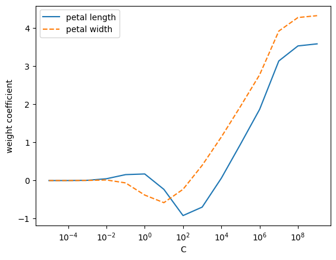

```python
weights, params = [], []
for c in np.arange(-5, 10):
    lr = LogisticRegression(C=10**(c*1.0), random_state=0)
    lr.fit(X_train_std, y_train)
    weights.append(lr.coef_[1]) # for a target class
    params.append(10**(c*1.0))
weights = np.array(weights)
plt.plot(params, weights[:, 0],
         label='petal length')
plt.plot(params, weights[:, 1], linestyle='--',
         label='petal width')
plt.ylabel('weight coefficient')
plt.xlabel('C')
plt.legend(loc='upper left')
plt.xscale('log')
plt.show()

# 在这段代码中，我们在一个范围内遍历了不同的C值（通过10**(c*1.0)计算得到），对每个C值，我们都训练了一个逻辑回归模型，并保存了模型的权重和对应的C值。
# 然后，我们将模型对于两个特征（'petal length'和'petal width'）的权重随C值的变化绘制在同一张图上。
```

### 最大间隔分类与支持向量机SVM

- 线性分类器回顾
  - 在样本空间中寻找一个超平面, 将不同类别的样本分开
- 将训练样本分开的超平面可能有很多, 哪一个更好呢?
  - ”正中间”的: 鲁棒性最好, 泛化能力最强
- 间隔(margin)与支持向量(support vector)
  - 超平面方程: $\boldsymbol{w}^{\top} \boldsymbol{x}+b=0$

[figure not shown]

- 支持向量机算法的基本思想
  - 支持向量机(Support Vector Machine，简称SVM)是一种常见的机器学习算法，其基本思想是在高维空间中构建一个超平面，用于分类或回归任务。
  - 具体而言，SVM首先将数据映射到高维空间，并在该空间中找到一个最优的超平面，使得该超平面能够将不同类别的数据点有效地分开。
  - 其中，对于最优超平面的定义是使得间隔最大化，即离超平面最近的数据点到超平面的距离最大化。这些最靠近超平面的样本点被称为支持向量。
  - SVM最终分类的过程是将新的数据点映射到高维空间，并根据其位置与最优超平面的关系来进行分类。如果新数据点在超平面正侧，则属于正类；反之则属于负类。
- 通过松弛变量解决非线性切分情况

[figure not shown]

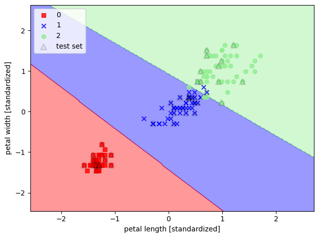

```python
from sklearn.svm import SVC

svm = SVC(kernel='linear', C=1.0, random_state=0)
svm.fit(X_train_std, y_train)

plot_decision_regions(X_combined_std, y_combined,
                      classifier=svm, test_idx=range(105, 150))
plt.xlabel('petal length [standardized]')
plt.ylabel('petal width [standardized]')
plt.legend(loc='upper left')
plt.tight_layout()
# plt.savefig('./figures/support_vector_machine_linear.png', dpi=300)
plt.show()
```

### 神奇的SVM核函数完成非线性切分

- 使用核函数解决线性不可分问题
- “核函数选择”成为决定支持向量机性能的关键!
- 常用核函数:

$$ \begin{aligned} &\begin{array}{lll} \hline \text { 名称 } & \text { 表达式 } & \text { 参数 } \\ \hline \text { 线性核 } & \kappa\left(\boldsymbol{x}_i, \boldsymbol{x}_j\right)=\boldsymbol{x}_i^{\mathrm{T}} \boldsymbol{x}_j & \\ \text { 多项式核 } & \kappa\left(\boldsymbol{x}_i, \boldsymbol{x}_j\right)=\left(\boldsymbol{x}_i^{\mathrm{T}} \boldsymbol{x}_j\right)^d & d \geqslant 1 \text { 为多项式的次数 } \\ \text { 高斯核 } & \kappa\left(\boldsymbol{x}_i, \boldsymbol{x}_j\right)=\exp \left(-\frac{\left\|\boldsymbol{x}_i-\boldsymbol{x}_j\right\|^2}{2 \sigma^2}\right) & \sigma>0 \text { 为高斯核的带宽(width) } \\ \text { 拉普拉斯核 } & \kappa\left(\boldsymbol{x}_i, \boldsymbol{x}_j\right)=\exp \left(-\frac{\left\|\boldsymbol{x}_i-\boldsymbol{x}_j\right\|}{\sigma}\right) & \sigma>0 \\ \text { Sigmoid 核 } & \kappa\left(\boldsymbol{x}_i, \boldsymbol{x}_j\right)=\tanh \left(\beta \boldsymbol{x}_i^{\mathrm{T}} \boldsymbol{x}_j+\theta\right) & \tanh \text { 为双曲正切函数, } \beta>0, \theta<0 \\ \hline \end{array} \end{aligned} $$

- 基本经验:文本数据常用线性核，情况不明时可先尝试高斯核.

[figure not shown]

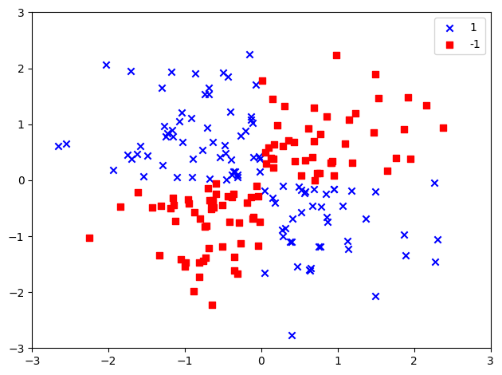

```python
import matplotlib.pyplot as plt
import numpy as np

np.random.seed(0)
X_xor = np.random.randn(200, 2)
y_xor = np.logical_xor(X_xor[:, 0] > 0,
                       X_xor[:, 1] > 0)
y_xor = np.where(y_xor, 1, -1)

plt.scatter(X_xor[y_xor == 1, 0],
            X_xor[y_xor == 1, 1],
            c='b', marker='x',
            label='1')
plt.scatter(X_xor[y_xor == -1, 0],
            X_xor[y_xor == -1, 1],
            c='r',
            marker='s',
            label='-1')

plt.xlim([-3, 3])
plt.ylim([-3, 3])
plt.legend(loc='best')
plt.tight_layout()
plt.show()
```

### 使用kernel trick在高维空间内找到一个可切分的超平面

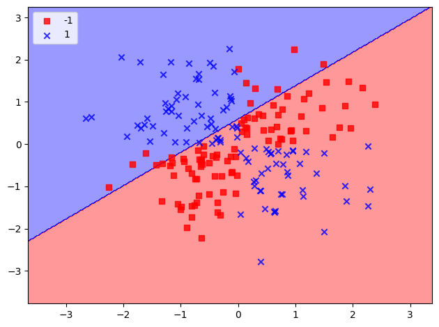

```python
# 先试下线性核
# 如果 kernel 为 ‘linear’，那么就使用线性核函数计算 kernelValue，这里直接使用矩阵乘法计算所有训练样本与待计算样本的内积；
svm = SVC(kernel='linear', random_state=0, gamma=0.10, C=10.0)
svm.fit(X_xor, y_xor)
plot_decision_regions(X_xor, y_xor,
                      classifier=svm)

plt.legend(loc='upper left')
plt.tight_layout()
plt.show()
```

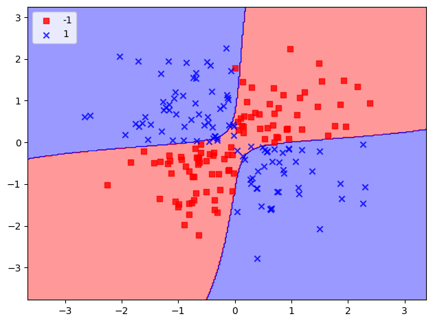

```python
# 如果 kernel 为 ‘rbf’，那么就使用径向基函数（RBF）核计算 kernelValue，这里计算每个训练样本与待计算样本之间的欧氏距离，并根据参数 sigma 计算出高斯核函数的值。
svm = SVC(kernel='rbf', random_state=0, gamma=0.10, C=10.0) # 高斯核 rbf: Radial Basis Function
svm.fit(X_xor, y_xor)
plot_decision_regions(X_xor, y_xor,
                      classifier=svm)

plt.legend(loc='upper left')
plt.tight_layout()
plt.show()
```

- 在实际应用中，往往依赖先验领域知识/交叉验证等方案才能选择有效的核函数。
  - 没有更多先验信息，则使用高斯核函数

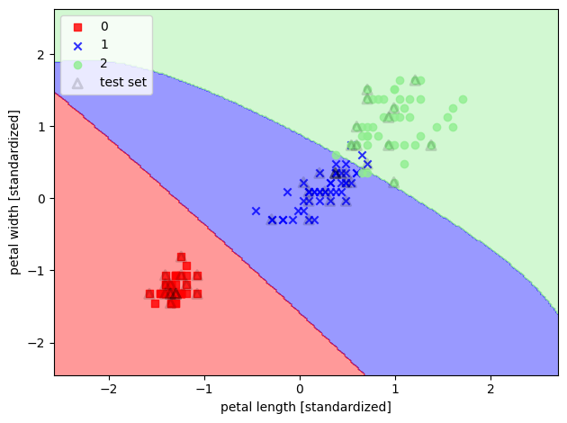

```python
svm = SVC(kernel='rbf', random_state=0, gamma=0.2, C=1.0)
svm.fit(X_train_std, y_train)

plot_decision_regions(X_combined_std, y_combined,
                      classifier=svm, test_idx=range(105, 150))
plt.xlabel('petal length [standardized]')
plt.ylabel('petal width [standardized]')
plt.legend(loc='upper left')
plt.tight_layout()
plt.show()
```

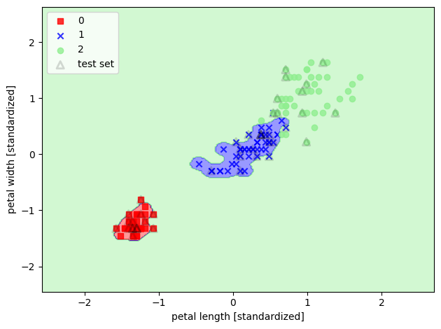

```python
svm = SVC(kernel='rbf', random_state=0, gamma=100.0, C=1.0)
svm.fit(X_train_std, y_train)

plot_decision_regions(X_combined_std, y_combined,
                      classifier=svm, test_idx=range(105, 150))
plt.xlabel('petal length [standardized]')
plt.ylabel('petal width [standardized]')
plt.legend(loc='upper left')
plt.tight_layout()
plt.show()
```

- 不同核函数与参数对分类的影响

[figure not shown]

支持向量机（SVM）算法在分类性能上的表现受到参数设定的影响较大，其中两个主要的参数是核函数类型和正则化参数。不同的参数设定可能会对SVM的分类性能产生不同的影响。以下是比较不同参数设定下SVM分类性能的方法：

- 核函数类型：
  - SVM算法采用核函数实现对数据特征空间的映射，从而实现非线性分类。通常情况下，我们可以使用多项式核函数、径向基函数等不同类型的核函数来处理不同的数据集。
- 正则化参数：
  - SVM中的正则化参数C对模型复杂度和泛化能力有重要影响。当C的值较小时，相当于对模型做了更强的正则化，更倾向于选择一个较小的分隔超平面，性能更加稳定，但容易产生欠拟合；当C的值较大时，相当于对模型的约束比较少，可能出现过拟合的情况。

因此，对比SVM在不同参数设定下的分类性能，需要进行实验比较：

1. 选取几类不同的核函数类型，比较它们在相同的数据集上的分类性能；
2. 在使用相同核函数的情况下，对C参数进行调整，比较它们的分类性能；
3. 绘制学习曲线和验证曲线来判断模型是否过拟合或欠拟合。

通过以上实验比较，可以得出最优的SVM参数设定，以达到最好的分类性能。需要注意的是，SVM的参数设定与数据集密切相关，需要针对不同的数据集进行调整。

- SVM的优缺点：

优点：

1. 在高维空间中⾮常高效；
2. 即使在数据维度⽐样本数量⼤的情况下仍然有效；
3. 在决策函数（称为支持向量）中使用训练集的子集,因此它也是⾼效利用内存的；
4. 通用性：不同的核函数与特定的决策函数⼀⼀对应；

缺点：

1. SVM算法对于大规模数据处理较为困难，计算复杂度较高；
2. 对于多分类问题，需要进行多次二分类，计算量较大；
3. 对于不平衡数据集，SVM算法可能会出现过拟合的情况；
4. SVM算法在确定核函数类型、参数设置等方面存在一定的主观性和经验性。
- ICDM 2006 会议的算法投票结果
  - 共有145人参加了ICDM 2006 Panel (会议的专题讨论)，并对18种候选算法进行投票，选出了机器学习10大算法

[figure not shown]

  - C4.5 算法是由Ross Quinlan开发的用于产生决策树的算法，采用信息增益率替代信息增益。
  - CART 算法，以基尼系数替代熵，最小化不纯度，而不是最大化信息增益。
- 信息论的视角理解

[figure not shown]

  - 用信息论的视角来观察：机器学习其实是破解密码的过程 $$ \begin{array}{|c|c|} \hline \text { 信息论的视角 } & \text { 机器学习的视角 } \\ \hline \text { 接受信号 } & \text { 特征 } \\ \hline \text { 信源 } & \text { 标签 } \\ \hline \text { 平均互信息 } & \text { 特征有效性分析 } \\ \hline \text { 最大熵模型 } & \text { 极大似然法 } \\ \hline \text { 交叉摘 } & \text { 逻辑回归损失函数 } \\ \hline \end{array} $$

### 决策树模型完成分类

决策树基于“树”结构进行决策

- 每个“内部结点”对应于某个属性上的“测试”(test)
- 每个分支对应于该测试的一种可能结果(即该属性的某个取值)
- 每个“叶结点”对应于一个“预测结果”

[figure not shown]

### 构建决策树

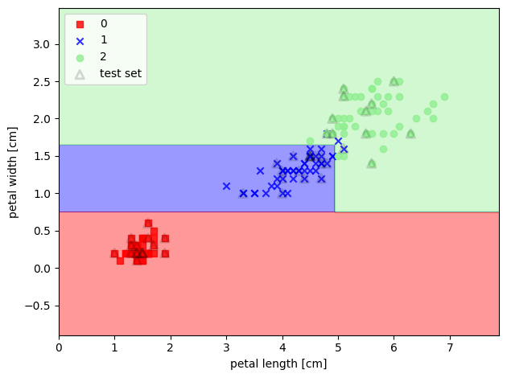

```python
from sklearn.tree import DecisionTreeClassifier

tree = DecisionTreeClassifier(criterion='entropy', max_depth=3, random_state=0)
tree.fit(X_train, y_train)

X_combined = np.vstack((X_train, X_test))
y_combined = np.hstack((y_train, y_test))
plot_decision_regions(X_combined, y_combined,
                      classifier=tree, test_idx=range(105, 150))

plt.xlabel('petal length [cm]')
plt.ylabel('petal width [cm]')
plt.legend(loc='upper left')
plt.tight_layout()
plt.show()
```

```python
from sklearn.tree import export_graphviz

export_graphviz(tree,
                out_file='tree.dot',
                feature_names=['petal length', 'petal width'])
```

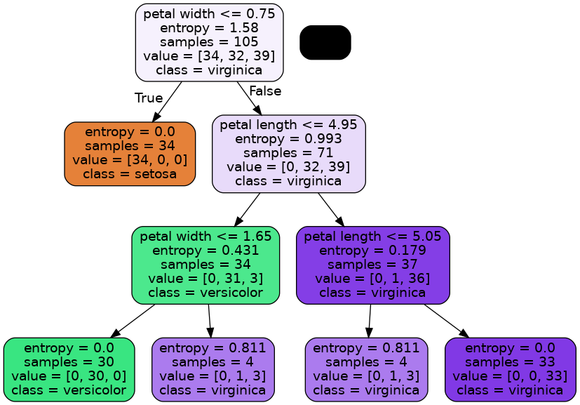

```python
from IPython.display import Image
from IPython.display import display

try:
    # !pip install pydotplus
    import pydotplus

    dot_data = export_graphviz(
    tree,
    out_file=None,
    # the parameters below are new in sklearn 0.18
    feature_names=['petal length', 'petal width'],
    class_names=['setosa', 'versicolor', 'virginica'],
    filled=True,
    rounded=True)

    # https://graphviz.org/download/
    # sudo yum install graphviz or apt install graphviz
    graph = pydotplus.graph_from_dot_data(dot_data)
    display(Image(graph.create_png()))

except ImportError:
    print('pydotplus is not installed.')
```

**点击折叠/展开**

[figure not shown]

### 树模型集成与随机森林

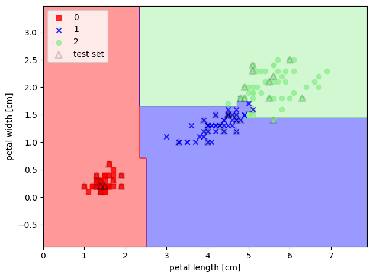

```python
from sklearn.ensemble import RandomForestClassifier

forest = RandomForestClassifier(criterion='entropy',
                                n_estimators=10, # The number of trees in the forest.
                                random_state=1,
                                n_jobs=2)
forest.fit(X_train, y_train)

plot_decision_regions(X_combined, y_combined,
                      classifier=forest, test_idx=range(105, 150))

plt.xlabel('petal length [cm]')
plt.ylabel('petal width [cm]')
plt.legend(loc='upper left')
plt.tight_layout()
plt.show()
```

### K 最近邻

- K最近邻(k-Nearest Neighbor，KNN)分类算法，是一个理论上比较成熟的方法，也是最简单的机器学习算法之一。
- 该方法的思路是：在特征空间中，如果一个样本附近的k个最近(即特征空间中最邻近)样本的大多数属于某一个类别，则该样本也属于这个类别。
- 该方法在确定分类决策上只依据最邻近的一个或者几个样本的类别来决定待分样本所属的类别。

[figure not shown]

> 上图对应的是：K = 5

[figure not shown]

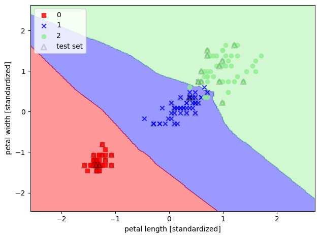

```python
from sklearn.neighbors import KNeighborsClassifier

knn = KNeighborsClassifier(n_neighbors=5, p=2, metric='minkowski')
knn.fit(X_train_std, y_train)

plot_decision_regions(X_combined_std, y_combined,
                      classifier=knn, test_idx=range(105, 150))

plt.xlabel('petal length [standardized]')
plt.ylabel('petal width [standardized]')
plt.legend(loc='upper left')
plt.tight_layout()
plt.show()
```

## Bonus: K-means 聚类算法

- 基于相似性度量，将相近的样本归为同一个子集，使得相同子集中各元素间差异性最小，而不同子集间的元素差异性最大。
- 这就是（空间）聚类算法的本质。而K-Means正是这样一种算法的代表。

[figure not shown]

先来完整地过一遍算法，其步骤具体地：

STEP 1 从N个样本数据中随机选**K个对象**，作为**初始的聚类中心**；

STEP 2 分别计算每个样本点到各个聚类中心的距离，并逐个**分配到距离其最近的簇**中；

STEP 3 所有对象分配完成后，**更新K个类中心位置**，类中心定义为簇内所有对象在各个维度的均值；

STEP 4 与前一次计算得到的K个聚类中心比较，如果聚类中心发生变化，转至步骤2，否则转至步骤5；

STEP 5 当类中心不再发生变化，停止并输出聚类结果，然后整理我们所需要的信息，如各个样本所属的类等等，进行后续的统计和分析。

容易看出，聚类结束之前，类中心会不断移动，而随着类中心的移动，样本的划分情况也会持续发生改变。

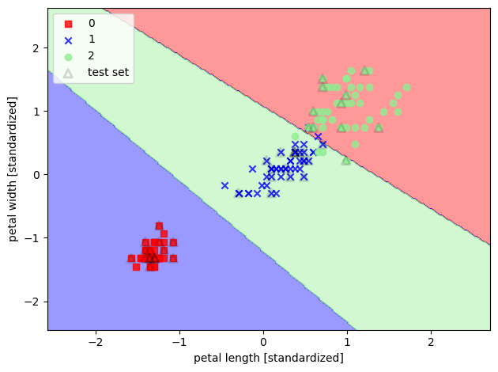

```python
from sklearn.cluster import KMeans

kmeans = KMeans(n_clusters=3,)
kmeans.fit(X_train_std#, y_train
          )

plot_decision_regions(X_combined_std, y_combined,
                      classifier=kmeans, test_idx=range(105, 150))

plt.xlabel('petal length [standardized]')
plt.ylabel('petal width [standardized]')
plt.legend(loc='upper left')
plt.tight_layout()
plt.show()
```

输入参数：

1. n_cluster：聚类个数（即K），默认值是8。
2. init：初始化类中心的方法（即选择初始中心点的根据），默认“K-means++”，其他可选参数包括“random”。
3. n_init：使用不同类中心运行的次数，默认值是10，即算法会初始化10次簇中心，然后返回最好的一次聚类结果。
4. max_iter：单次运行KMeans算法的最大迭代次数，默认值是300。
5. tol：浮点型，两次迭代之间簇内平方和下降的容忍阈值，默认为0.0001，如果两次迭代之间下降的值小于tol所设定的值，迭代就会停下。
6. verbose:是否输出详细信息，参数类型为整型，默认值为0，1表示每隔一段时间打印一次日志信息。
7. random_state：控制每次类中心随机初始化的随机种子，作用相当于能够锁定和复现同一次随机结果，默认为none，也可以随机设置数字。
8. copy_x：在预先计算距离时，首先将数据居中在数值上更准确。如果 copy_x 为 True(默认)，则不修改原始数据。如果为 False，则修改原始数据，并在函数返回之前放回，但通过减去再添加数据均值可能会引入小的数值差异。请注意，如果原始数据不是C-contiguous，即使copy_x 为False，也会进行复制。如果原始数据是稀疏的，但不是 CSR 格式，即使 copy_x 为 False，也会进行复制。
9. algorithm：有三种参数可选：auto”, “full”, “elkan”，默认为auto。K-means 算法使用。经典的EM-style算法是“full”。通过使用三角不等式，“elkan” 变体对具有明确定义的集群的数据更有效。然而，由于分配了一个额外的形状数组(n_samples，n_clusters)，它更加占用内存。

输出的属性：

1. cluster_centers_:最终聚类中心的坐标；
2. labels_:每个样本点对应的类别标签；
3. inertia_:每个样本点到距离它们最近的类中心的距离平方和，即SSE；
4. n_iter:实际的迭代次数；
5. n_features_in_:参与聚类的特征个数；
6. feature_names_in_:参与聚类的特征名称。

```python
kmeans.n_iter_
```

```
3
```

```python
kmeans.cluster_centers_
```

```
array([[ 0.99659816,  1.06264444],
       [-1.32276406, -1.28193688],
       [ 0.21524993,  0.09713228]])
```

- K-Means聚类由于其本身原理通俗易懂、执行简单有效、聚类速度快、聚类结果可解释性强的优点，得到了广泛的应用。
- 然而，传统的K-Means也存在不少缺陷，比如对K值的选择没有准则可依循，聚类结果的好坏依赖于对初始聚类中心的选择，容易陷入局部最优解，对异常数据较为敏感，只能处理数值属性的数据，聚类结果可能不平衡等等。
- 因此我们往往会从K值的选取、初始聚类中心点的选取、相似性和距离度量、离群点的检测和去除等方面对算法进行改进。